# Compare CellRanger vs scUTRquant Counts - PBMC

Mervin Fansler

15 June 2022

# Overview

Here we compare the count results of CellRanger versus scUTRquant using the 10X Chromium 3’-end demonstration data (v2 and v3). This gauges consistency with gene-level count pipelines, indicating the appropriateness for substituting scUTRquant for alternative scRNA-seq quantification tools. CellRanger counts are based on a CellRanger-filtered version of Ensembl Release 93 for GRCh38. sqUTRquant counts use a human UTRome build based on GENCODE v39 augmented with cleavage sites called from the Human Cell Landscape (Han et al., *Nature*, 2020).

# Libraries

```r
library(SingleCellExperiment)
library(DropletUtils)
library(tidyverse)
library(ggbeeswarm)
library(ggrastr)
library(magrittr)
library(cowplot)
library(Matrix)
```

# Data

```r
SAMPLE_SHEET="metadata/counts_sample_sheet_pbmc_utrome.csv"

## conform 10X cell ids to match scUTRquant cell_id
conform_cell_ids <- function (sample_id, sce) {
  colData(sce) %<>%
    as_tibble %>%
    mutate(bx=str_extract(Barcode, "^[ACGT]{16}"),
           cell_id=str_c(sample_id, bx, sep='_')) %>%
    select(cell_id, bx) %>%
    set_rownames(.$cell_id) %>%
    DataFrame()
  sce
}

## conform to unversioned ENSEMBL gene_id
conform_gene_ids <- function (sce) {
  set_rownames(sce, str_extract(rownames(sce), "^ENSG[0-9]+"))
}

df_counts <- read_csv(SAMPLE_SHEET) %>%
  ## read SCE files
  mutate(sce_sq=map(file_scutrquant, readRDS),
         sce_10x=map(file_cellranger, read10xCounts)) %>%

  ## adjust cell_ids
  mutate(sce_10x=map2(sample_id, sce_10x, conform_cell_ids)) %>%

  ## summarize to gene counts
  mutate(sce_sq=map(sce_sq, conform_gene_ids))
```

# UMI Counts Per Cell

## Compute Correlations

```r
compute_cell_correlation <- function (sce1, sce2, method="pearson") {
  idx_cells <- intersect(colnames(sce1), colnames(sce2))
  cts1 <- log10(colSums(counts(sce1[,idx_cells])))
  cts2 <- log10(colSums(counts(sce2[,idx_cells])))
  cor(cts1, cts2, method=method)
}

df_cells_prho <- df_counts %>%
  transmute(sample_id, rho=map2_dbl(sce_sq, sce_10x, compute_cell_correlation, method='pearson')) %T>%
  knitr::kable()

df_cells_srho <- df_counts %>%
  transmute(sample_id, rho=map2_dbl(sce_sq, sce_10x, compute_cell_correlation, method='spearman')) %T>%
  knitr::kable()
```

## Plots

### Correlations

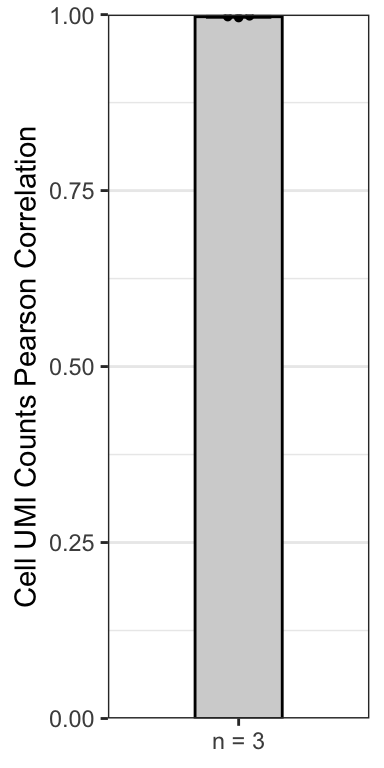

```r
n_lab <- sprintf("n = %d", nrow(df_cells_prho))

df_cells_prho %>%
  ggplot(aes(x=n_lab, y=rho)) +
  stat_summary(fun='mean', geom='bar', width=0.4, fill='lightgrey', color='black') +
  stat_summary(fun.data=mean_se, geom='errorbar', width=0.3) +
  geom_quasirandom(width=0.1, size=1) +
  scale_y_continuous(limits=c(0,1), expand=expansion(add=c(0,0))) +
  labs(x=NULL, y="Cell UMI Counts Pearson Correlation") +
  theme_bw()
```

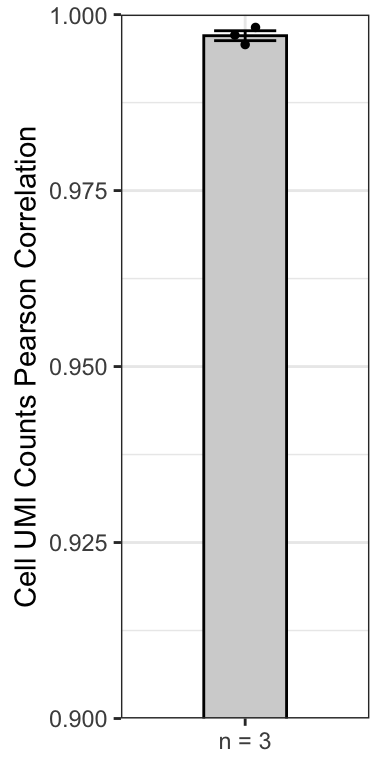

```r
ggsave("output/figure5/utrome/fig5A-umi-corrs-pearson-inset.pdf", width=2, height=4, dpi=300)

df_cells_prho %>%
  ggplot(aes(x=n_lab, y=rho)) +
  stat_summary(fun='mean', geom='bar', width=0.4, fill='lightgrey', color='black') +
  stat_summary(fun.data=mean_se, geom='errorbar', width=0.3) +
  geom_quasirandom(width=0.1, size=1) +
  scale_y_continuous(limits=c(0,1), expand=expansion(add=c(0,0))) +
  coord_cartesian(ylim=c(0.9,1)) +
  labs(x=NULL, y="Cell UMI Counts Pearson Correlation") +
  theme_bw()
```

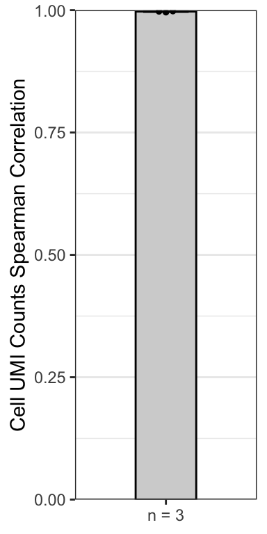

```r
ggsave("output/figure5/utrome/fig5A-umi-corrs-pearson-inset-zoom.pdf", width=2, height=4, dpi=300)

df_cells_srho %>%
  ggplot(aes(x=n_lab, y=rho)) +
  stat_summary(fun='mean', geom='bar', width=0.4, fill='lightgrey', color='black') +
  stat_summary(fun.data=mean_se, geom='errorbar', width=0.3) +
  geom_quasirandom(width=0.1, size=1) +
  scale_y_continuous(limits=c(0,1), expand=expansion(add=c(0,0))) +
  labs(x=NULL, y="Cell UMI Counts Spearman Correlation") +
  theme_bw()
```

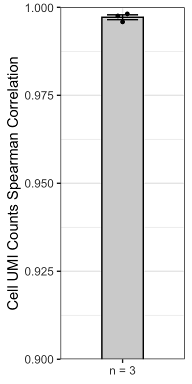

```r
ggsave("output/figure5/utrome/fig5A-umi-corrs-spearman-inset.pdf", width=2, height=4, dpi=300)

df_cells_srho %>%
  ggplot(aes(x=n_lab, y=rho)) +
  stat_summary(fun='mean', geom='bar', width=0.4, fill='lightgrey', color='black') +
  stat_summary(fun.data=mean_se, geom='errorbar', width=0.3) +
  geom_quasirandom(width=0.1, size=1) +
  scale_y_continuous(limits=c(0,1), expand=expansion(add=c(0,0))) +
  coord_cartesian(ylim=c(0.9,1)) +
  labs(x=NULL, y="Cell UMI Counts Spearman Correlation") +
  theme_bw()
```

```r
ggsave("output/figure5/utrome/fig5A-umi-corrs-spearman-inset-zoom.pdf", width=2, height=4, dpi=300)
```

### Dots

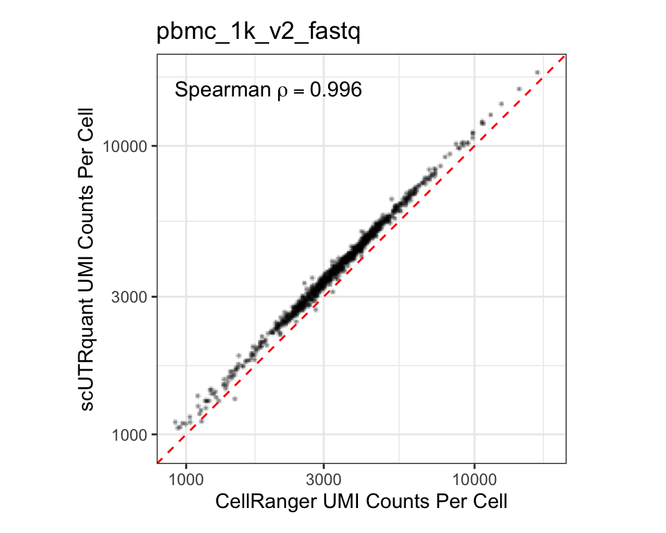

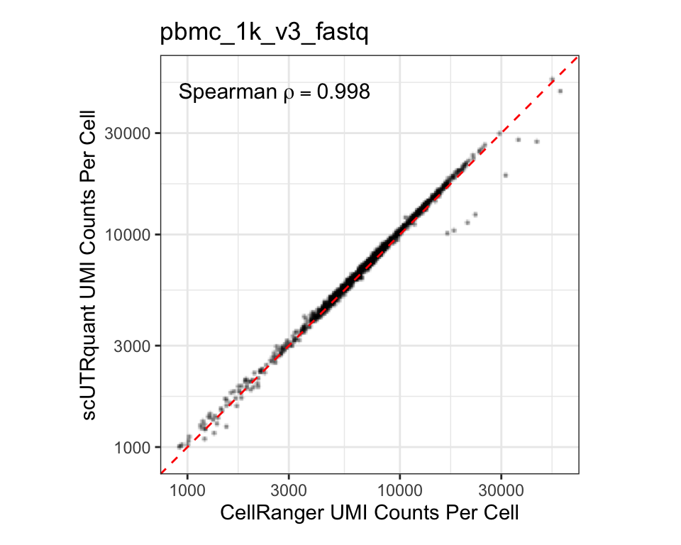

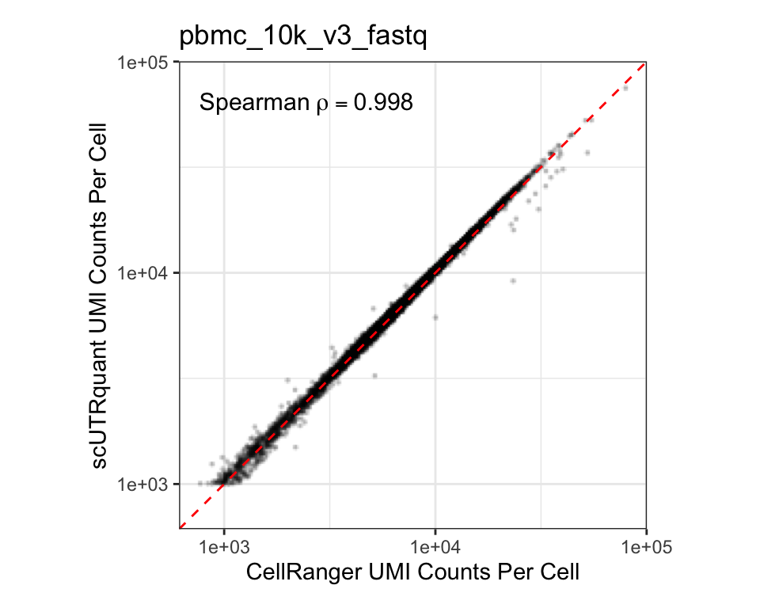

```r
plot_umis_per_cell_compare <- function (sce_x, sce_y,
                                        label_x="CellRanger UMI Counts Per Cell",
                                        label_y="scUTRquant UMI Counts Per Cell") {
  idx_cells <- intersect(colnames(sce_x), colnames(sce_y))
  df <- tibble(x=colSums(counts(sce_x[,idx_cells])),
               y=colSums(counts(sce_y[,idx_cells])))
  alpha <- if (nrow(df) > 5000) 0.3 else 0.5
  axis_lims <- c(min(df$x,df$y), max(df$x,df$y))
  label_rho_s <- sprintf("\"Spearman\" ~ rho == \"%0.3f\"",
                         cor(df$x, df$y, method='spearman'))
  label_lims <- axis_lims %>% { c(.[1]^0.75*.[2]^0.25, .[1]^0.05*.[2]^0.95)}
  ggplot(df, aes(x=x, y=y)) +
    rasterize(geom_point(alpha=alpha, size=0.3, pch=16)) +
    annotate("text", x=label_lims[1], y=label_lims[2], label=label_rho_s, size=4, parse=TRUE) +
    geom_abline(slope=1, intercept=0, linetype='dashed', color="red") +
    scale_x_log10(limits=axis_lims) + scale_y_log10(limits=axis_lims) +
    labs(x=label_x, y=label_y) +
    theme_bw() +
    theme(plot.margin=grid::unit(c(4,8,4,4), "mm"), aspect.ratio=1)
}

df_counts %>%
  transmute(sample_id, g=map2(sce_10x, sce_sq, plot_umis_per_cell_compare)) %>%
  deframe() %>% {
    for (id in names(.)) {
      ## print locally in this document
      print(.[[id]] + ggtitle(id))

      ## save to PDFs
      ggsave(sprintf("output/figure5/utrome/fig5A-umis-per-cell-compare-%s.pdf", id),
             .[[id]], width=5, height=4, dpi=300)
    }
  }
```

# UMI Counts Per Gene

## Compute Correlations

```r
compute_gene_correlation <- function (sce1, sce2, method="pearson") {
  idx_genes <- intersect(rownames(sce1), rownames(sce2))
  idx_cells <- intersect(colnames(sce1), colnames(sce2))
  cts1 <- log10(1+rowSums(counts(sce1[idx_genes,idx_cells])))
  cts2 <- log10(1+rowSums(counts(sce2[idx_genes,idx_cells])))
  cor(cts1, cts2, method=method)
}

df_genes_prho <- df_counts %>%
  transmute(sample_id, rho=map2_dbl(sce_sq, sce_10x, compute_gene_correlation, method='pearson')) %T>%
  { print(knitr::kable(.)) }
```

```
##
##
## |sample_id         |       rho|
## |:-----------------|---------:|
## |pbmc_1k_v2_fastq  | 0.8893978|
## |pbmc_1k_v3_fastq  | 0.8976585|
## |pbmc_10k_v3_fastq | 0.8995164|
```

```r
df_genes_srho <- df_counts %>%
  transmute(sample_id, rho=map2_dbl(sce_sq, sce_10x, compute_gene_correlation, method='spearman')) %T>%
  { print(knitr::kable(.)) }
```

```
##
##
## |sample_id         |       rho|
## |:-----------------|---------:|
## |pbmc_1k_v2_fastq  | 0.8797427|
## |pbmc_1k_v3_fastq  | 0.8888071|
## |pbmc_10k_v3_fastq | 0.8892882|
```

## Plots

### Correlations

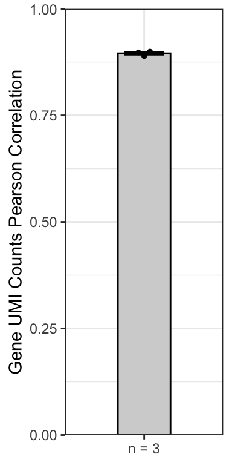

```r
n_lab <- sprintf("n = %d", nrow(df_genes_prho))

df_genes_prho %>%
  ggplot(aes(x=n_lab, y=rho)) +
  stat_summary(fun='mean', geom='bar', width=0.4, fill='lightgrey', color='black') +
  stat_summary(fun.data=mean_se, geom='errorbar', width=0.3) +
  geom_quasirandom(width=0.1, size=1) +
  scale_y_continuous(limits=c(0,1), expand=expansion(add=c(0,0))) +
  labs(x=NULL, y="Gene UMI Counts Pearson Correlation") +
  theme_bw()
```

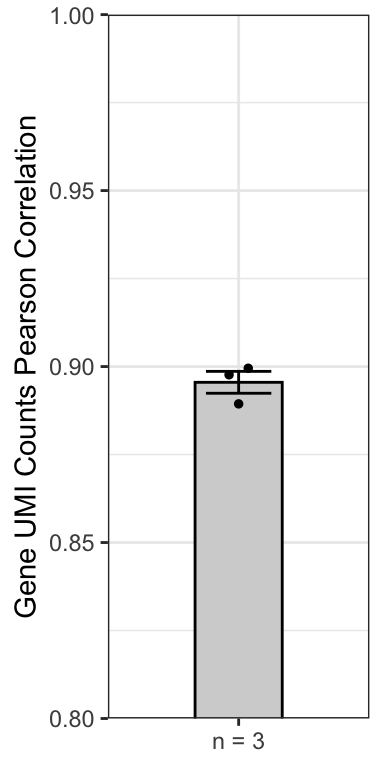

```r
ggsave("output/figure5/utrome/fig5B-umi-corrs-pearson-inset.pdf", width=2, height=4, dpi=300)

df_genes_prho %>%
  ggplot(aes(x=n_lab, y=rho)) +
  stat_summary(fun='mean', geom='bar', width=0.4, fill='lightgrey', color='black') +
  stat_summary(fun.data=mean_se, geom='errorbar', width=0.3) +
  geom_quasirandom(width=0.1, size=1) +
  scale_y_continuous(limits=c(0,1), expand=expansion(add=c(0,0))) +
  coord_cartesian(ylim=c(0.8,1)) +
  labs(x=NULL, y="Gene UMI Counts Pearson Correlation") +
  theme_bw()
```

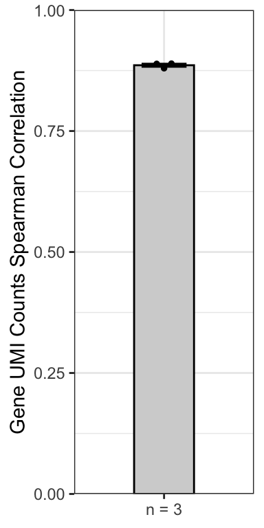

```r
ggsave("output/figure5/utrome/fig5B-umi-corrs-pearson-inset-zoom.pdf", width=2, height=4, dpi=300)

df_genes_srho %>%
  ggplot(aes(x=n_lab, y=rho)) +
  stat_summary(fun='mean', geom='bar', width=0.4, fill='lightgrey', color='black') +
  stat_summary(fun.data=mean_se, geom='errorbar', width=0.3) +
  geom_quasirandom(width=0.1, size=1) +
  scale_y_continuous(limits=c(0,1), expand=expansion(add=c(0,0))) +
  labs(x=NULL, y="Gene UMI Counts Spearman Correlation") +
  theme_bw()
```

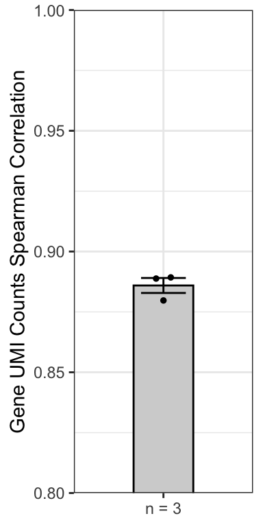

```r
ggsave("output/figure5/utrome/fig5B-umi-corrs-spearman-inset.pdf", width=2, height=4, dpi=300)

df_genes_srho %>%
  ggplot(aes(x=n_lab, y=rho)) +
  stat_summary(fun='mean', geom='bar', width=0.4, fill='lightgrey', color='black') +
  stat_summary(fun.data=mean_se, geom='errorbar', width=0.3) +
  geom_quasirandom(width=0.1, size=1) +
  scale_y_continuous(limits=c(0,1), expand=expansion(add=c(0,0))) +
  coord_cartesian(ylim=c(0.8,1)) +
  labs(x=NULL, y="Gene UMI Counts Spearman Correlation") +
  theme_bw()
```

```r
ggsave("output/figure5/utrome/fig5B-umi-corrs-spearman-inset-zoom.pdf", width=2, height=4, dpi=300)
```

### Dots

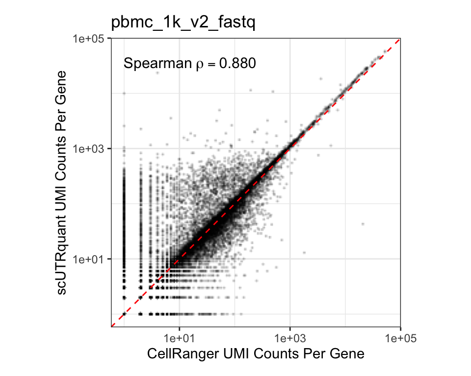

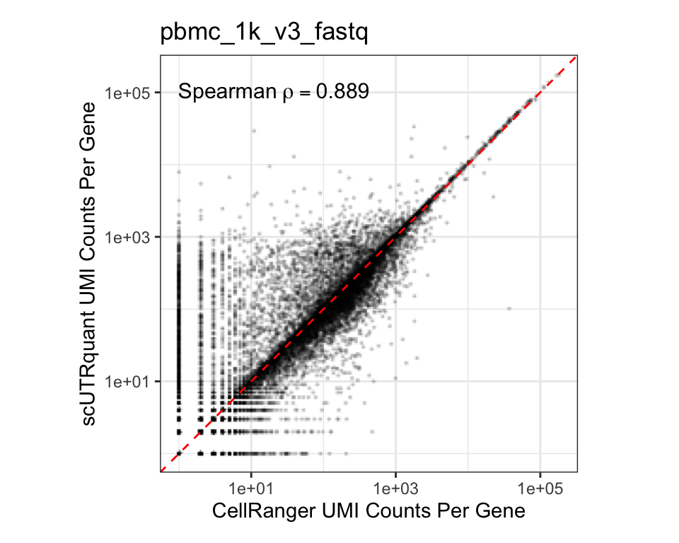

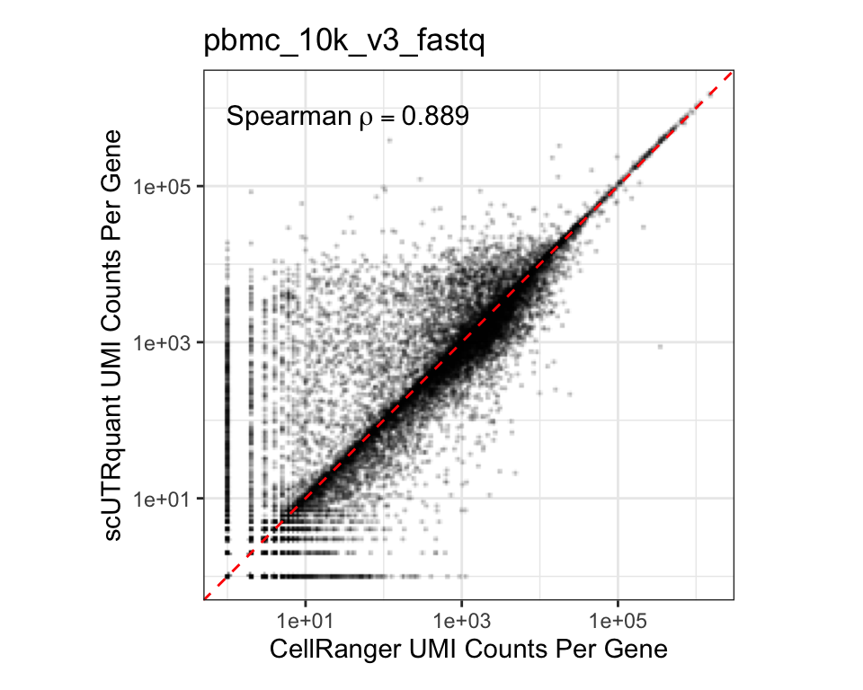

```r
plot_umis_per_gene_compare <- function (sce_x, sce_y,
                                        label_x="CellRanger UMI Counts Per Gene",
                                        label_y="scUTRquant UMI Counts Per Gene") {
  idx_genes <- intersect(rownames(sce_x), rownames(sce_y))
  idx_cells <- intersect(colnames(sce_x), colnames(sce_y))
  df <- tibble(x=rowSums(counts(sce_x[idx_genes,idx_cells])),
               y=rowSums(counts(sce_y[idx_genes,idx_cells])))
  axis_lims <- c(df$x, df$y) %>% { c(min(.), max(.)) + 1 }
  label_rho_s <- sprintf("\"Spearman\" ~ rho == \"%0.3f\"",
                         cor(df$x, df$y, method='spearman'))
  label_lims <- axis_lims %>% { c(.[1]^0.75*.[2]^0.25, .[1]^0.05*.[2]^0.95)}
  ggplot(df, aes(x=x+1, y=y+1)) +
    rasterize(geom_point(alpha=0.3, size=0.1, pch=16)) +
    annotate("text", x=label_lims[1], y=label_lims[2], label=label_rho_s, size=4, parse=TRUE) +
    geom_abline(slope=1, intercept=0, linetype='dashed', color="red") +
    scale_x_log10(limits=axis_lims) + scale_y_log10(limits=axis_lims) +
    labs(x=label_x, y=label_y) +
    theme_bw() +
    theme(plot.margin=grid::unit(c(4,8,4,4), "mm"), aspect.ratio=1)
}

df_counts %>%
  transmute(sample_id, g=map2(sce_10x, sce_sq, plot_umis_per_gene_compare)) %>%
  deframe() %>% {
    for (id in names(.)) {
      ## print locally in this document
      print(.[[id]] + ggtitle(id))

      ## save to PDFs
      ggsave(sprintf("output/figure5/utrome/fig5B-umis-per-gene-compare-%s.pdf", id),
             .[[id]], width=5, height=4, dpi=300)
    }
  }
```

# Runtime Details

## Conda Environment

[output not shown]

[output cut: 452 more lines]

[output not shown]